# MY PROJECT

01-11-2016

My distribution should be similar to others’ distributions who also collect random samples from this population, but it is likely not exactly the same since it’s a random sample.

1. True
2. False

answer: a

```r
sample_mean <- mean(samp)
se <- sd(samp)/sqrt(60)
lower <- sample_mean - 1.96 * se
upper <- sample_mean + 1.96 * se
```

1. The sample is random.
2. The sample size, 60, is less than 10% of all houses.
3. The sample distribution must be nearly normal.

answer: c

What does “95% confidence” mean?

1. 95% of the time the true average area of houses in Ames, Iowa, will be in this interval.
2. 95% of random samples of size 60 will yield confidence intervals that contain the true average area of houses in Ames, Iowa. 95% of the houses in Ames have an area in this interval.
3. 95% confident that the sample mean is in this interval.

answer: a

What proportion of 95% confidence intervals would you expect to capture the true population mean?

1. 1%
2. 5%
3. 95%
4. 99%

```r
samp_mean <- rep(NA, 50)
samp_sd <- rep(NA, 50)
n <- 60

for(i in 1:50){
  samp <- sample(population, n) # obtain a sample of size n = 60 from the population
  samp_mean[i] <- mean(samp)    # save sample mean in ith element of samp_mean
  samp_sd[i] <- sd(samp)        # save sample sd in ith element of samp_sd
}

lower <- samp_mean - 1.96 * samp_sd / sqrt(n)
upper <- samp_mean + 1.96 * samp_sd / sqrt(n)
c(lower[1],upper[1])
```

```
## [1] 1441.813 1687.787
```

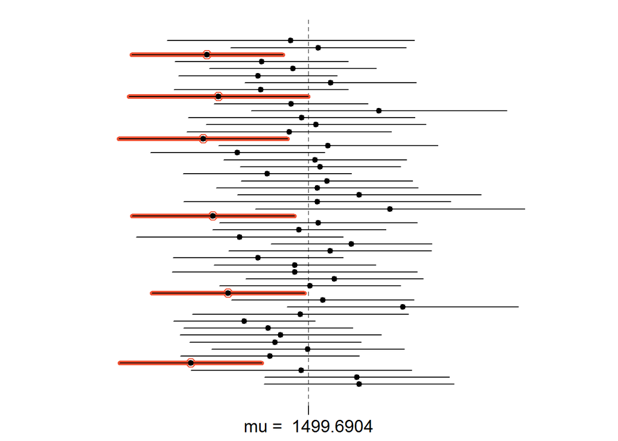

```r
plot_ci(lower, upper, mean(population))
```

What is the appropriate critical value for a 99% confidence level?

1. 0.01
2. 0.99
3. 1.96
4. 2.33
5. 2.58

```r
qnorm(.995)
```

```
## [1] 2.575829
```

answer: e

We would expect 99% of the intervals to contain the true population mean.

1. True
2. False

answer: true